# Dynamic Window GAM Analysis: Sunset Window (Max Count → Functional Sunset)

Author

Kyle Nessen

Published

October 1, 2025

## 1 Background and Rationale

This analysis addresses feedback from Francis regarding the temporal alignment of weather predictors with butterfly responses. The original daily-level analysis used fixed 6am-6pm weather windows, which Francis identified as having a temporal logic issue:

> “All of the metrics for wind, temperature and light, would need to be re-calculated for 24 hour periods that begin at the time of the highest count.”

### 1.1 Francis’s Key Points

1. **Temporal alignment**: Butterflies can only respond to weather *after* it occurs
2. **Biological timing**: If max count occurred at 2pm on day t-1, the relevant weather window should start at 2pm, not 6am
3. **Roosting decisions**: Weather from max count through sunset determines whether butterflies abandon the roost

### 1.2 This Analysis

**Weather window**: `time_of_max_count_t_1` → `last_observation_time_t` (functional sunset)

- Weather metrics now include **overnight conditions** (24/7 temperature and wind)
- Window lengths vary by observation (mean: 29.6 hours, range: 22.5-34.9 hours)
- Captures weather exposure until roosting decisions are finalized at dusk
- Tests the hypothesis: “Do weather conditions from peak count to sunset predict roost abandonment?”

**Data source**: `data/monarch_daily_lag_analysis_sunset_window.csv` (103 lag pairs)

## 2 Setup

```r
library(tidyverse)
library(mgcv)
library(knitr)
library(here)
library(corrplot)
library(patchwork)
library(gratia)

# Load the sunset window data
daily_data <- read_csv(here("data", "monarch_daily_lag_analysis_sunset_window.csv"))

# Create the square root transformed response variable
daily_data <- daily_data %>%
    mutate(
        butterfly_diff_95th_sqrt = ifelse(butterfly_diff_95th >= 0,
            sqrt(butterfly_diff_95th),
            -sqrt(-butterfly_diff_95th)
        )
    )
```

## 3 Data Overview

```r
cat("Dataset dimensions:", nrow(daily_data), "rows x", ncol(daily_data), "columns\n")
```

```
Dataset dimensions: 103 rows x 53 columns
```

```r
cat("Number of deployments:", n_distinct(daily_data$deployment_id), "\n")
```

```
Number of deployments: 7
```

```r
cat("Date range:", min(daily_data$date_t), "to", max(daily_data$date_t), "\n\n")
```

```
Date range: 19680 to 19756
```

```r
cat("Window characteristics:\n")
```

```
Window characteristics:
```

```r
cat("- Mean lag duration:", round(mean(daily_data$lag_duration_hours, na.rm = TRUE), 2), "hours\n")
```

```
- Mean lag duration: 29.56 hours
```

```r
cat("- Duration range:", round(min(daily_data$lag_duration_hours, na.rm = TRUE), 2), "-",
    round(max(daily_data$lag_duration_hours, na.rm = TRUE), 2), "hours\n")
```

```
- Duration range: 22.5 - 34.9 hours
```

```r
cat("- Median data completeness:", round(median(daily_data$metrics_complete, na.rm = TRUE), 3), "\n\n")
```

```
- Median data completeness: 1
```

```r
# Summary of key variables
summary_vars <- daily_data %>%
    select(
        butterflies_95th_percentile_t,
        butterflies_95th_percentile_t_1,
        butterfly_diff_95th,
        temp_max,
        temp_min,
        temp_at_max_count_t_1,
        wind_max_gust,
        sum_butterflies_direct_sun,
        lag_duration_hours,
        metrics_complete
    )

kable(summary(summary_vars), caption = "Summary statistics for key variables")
```

Summary statistics for key variables

|  | butterflies_95th_percentile_t | butterflies_95th_percentile_t_1 | butterfly_diff_95th | temp_max | temp_min | temp_at_max_count_t_1 | wind_max_gust | sum_butterflies_direct_sun | lag_duration_hours | metrics_complete |
| --- | --- | --- | --- | --- | --- | --- | --- | --- | --- | --- |
|  | Min. : 0.00 | Min. : 0.0 | Min. :-310.000 | Min. :14.00 | Min. : 3.000 | Min. : 5.00 | Min. : 0.000 | Min. : 0.0 | Min. :22.50 | Min. :0.0000 |
|  | 1st Qu.: 14.85 | 1st Qu.: 17.5 | 1st Qu.: -31.000 | 1st Qu.:17.00 | 1st Qu.: 6.000 | 1st Qu.:11.50 | 1st Qu.: 3.200 | 1st Qu.: 12.0 | 1st Qu.:25.50 | 1st Qu.:0.9996 |
|  | Median : 70.05 | Median : 77.0 | Median : -2.950 | Median :19.00 | Median : 8.000 | Median :14.00 | Median : 4.100 | Median : 42.0 | Median :30.50 | Median :0.9996 |
|  | Mean :107.41 | Mean :116.3 | Mean : -8.919 | Mean :20.47 | Mean : 8.311 | Mean :13.37 | Mean : 4.391 | Mean : 132.8 | Mean :29.56 | Mean :0.9593 |
|  | 3rd Qu.:166.95 | 3rd Qu.:199.5 | 3rd Qu.: 18.000 | 3rd Qu.:23.00 | 3rd Qu.:11.000 | 3rd Qu.:15.50 | 3rd Qu.: 5.100 | 3rd Qu.: 168.5 | 3rd Qu.:33.17 | 3rd Qu.:0.9997 |
|  | Max. :499.00 | Max. :499.0 | Max. : 256.600 | Max. :34.00 | Max. :14.000 | Max. :25.00 | Max. :12.800 | Max. :1122.0 | Max. :34.90 | Max. :0.9998 |
|  | NA | NA | NA | NA | NA | NA | NA’s :2 | NA | NA | NA |

## 4 Candidate Predictor Variables

Following the original analysis structure, we consider all potential weather and baseline metrics, then use correlation analysis to select final predictors.

### 4.1 All Candidate Variables

```r
# Define all candidate predictors
butterfly_baseline_vars <- c(
    "butterflies_95th_percentile_t_1",
    "max_butterflies_t_1",
    "butterflies_top3_mean_t_1"
)

temperature_vars <- c(
    "temp_max",
    "temp_min",
    "temp_mean",
    "temp_at_max_count_t_1",
    "hours_above_15C",
    "degree_hours_above_15C"
)

wind_vars <- c(
    "wind_avg_sustained",
    "wind_max_gust",
    "wind_gust_sum",
    "wind_gust_sum_above_2ms",
    "wind_gust_hours",
    "wind_minutes_above_2ms",
    "wind_gust_sd",
    "wind_mode_gust"
)

sun_vars <- c(
    "sum_butterflies_direct_sun"
)

window_vars <- c(
    "lag_duration_hours"
)

# Combine all candidates
all_predictors <- c(
    butterfly_baseline_vars,
    temperature_vars,
    wind_vars,
    sun_vars,
    window_vars
)

cat("Total candidate predictors:", length(all_predictors), "\n")
```

```
Total candidate predictors: 19
```

```r
cat("- Butterfly baseline:", length(butterfly_baseline_vars), "\n")
```

```
- Butterfly baseline: 3
```

```r
cat("- Temperature:", length(temperature_vars), "\n")
```

```
- Temperature: 6
```

```r
cat("- Wind:", length(wind_vars), "\n")
```

```
- Wind: 8
```

```r
cat("- Sun exposure:", length(sun_vars), "\n")
```

```
- Sun exposure: 1
```

```r
cat("- Window characteristics:", length(window_vars), "\n")
```

```
- Window characteristics: 1
```

### 4.2 Variable Descriptions

```r
var_descriptions <- tribble(
    ~Variable, ~Description, ~Type,
    "butterflies_95th_percentile_t_1", "95th percentile count on previous day (baseline)", "Baseline",
    "max_butterflies_t_1", "Maximum count on previous day", "Baseline",
    "butterflies_top3_mean_t_1", "Mean of top 3 counts on previous day", "Baseline",
    "temp_max", "Max temp from max count to sunset (includes overnight)", "Temperature",
    "temp_min", "Min temp from max count to sunset (includes overnight)", "Temperature",
    "temp_mean", "Mean temp from max count to sunset", "Temperature",
    "temp_at_max_count_t_1", "Temperature when max count occurred", "Temperature",
    "hours_above_15C", "Hours ≥15°C in window", "Temperature",
    "degree_hours_above_15C", "Cumulative degree-hours >15°C", "Temperature",
    "wind_avg_sustained", "Mean sustained wind speed in window", "Wind",
    "wind_max_gust", "Maximum gust in window (includes overnight)", "Wind",
    "wind_gust_sum", "Sum of all gust measurements", "Wind",
    "wind_gust_sum_above_2ms", "Sum of gusts >2 m/s", "Wind",
    "wind_gust_hours", "Gust-hours (integral)", "Wind",
    "wind_minutes_above_2ms", "Minutes with wind ≥2 m/s", "Wind",
    "wind_gust_sd", "SD of gust speeds (variability)", "Wind",
    "wind_mode_gust", "Most frequent gust speed", "Wind",
    "sum_butterflies_direct_sun", "Sum of butterflies in direct sun (entire lag window)", "Sun",
    "lag_duration_hours", "Window length in hours", "Window"
)

kable(var_descriptions, caption = "Candidate predictor variables")
```

Candidate predictor variables

| Variable | Description | Type |
| --- | --- | --- |
| butterflies_95th_percentile_t_1 | 95th percentile count on previous day (baseline) | Baseline |
| max_butterflies_t_1 | Maximum count on previous day | Baseline |
| butterflies_top3_mean_t_1 | Mean of top 3 counts on previous day | Baseline |
| temp_max | Max temp from max count to sunset (includes overnight) | Temperature |
| temp_min | Min temp from max count to sunset (includes overnight) | Temperature |
| temp_mean | Mean temp from max count to sunset | Temperature |
| temp_at_max_count_t_1 | Temperature when max count occurred | Temperature |
| hours_above_15C | Hours ≥15°C in window | Temperature |
| degree_hours_above_15C | Cumulative degree-hours >15°C | Temperature |
| wind_avg_sustained | Mean sustained wind speed in window | Wind |
| wind_max_gust | Maximum gust in window (includes overnight) | Wind |
| wind_gust_sum | Sum of all gust measurements | Wind |
| wind_gust_sum_above_2ms | Sum of gusts >2 m/s | Wind |
| wind_gust_hours | Gust-hours (integral) | Wind |
| wind_minutes_above_2ms | Minutes with wind ≥2 m/s | Wind |
| wind_gust_sd | SD of gust speeds (variability) | Wind |
| wind_mode_gust | Most frequent gust speed | Wind |
| sum_butterflies_direct_sun | Sum of butterflies in direct sun (entire lag window) | Sun |
| lag_duration_hours | Window length in hours | Window |

## 5 Data Quality Assessment

```r
cat("Data completeness summary:\n")
```

```
Data completeness summary:
```

```r
cat("- Observations with metrics_complete = 0:", sum(daily_data$metrics_complete == 0), "\n")
```

```
- Observations with metrics_complete = 0: 2
```

```r
cat("- Observations with wind_data_coverage < 0.5:", sum(daily_data$wind_data_coverage < 0.5), "\n")
```

```
- Observations with wind_data_coverage < 0.5: 5
```

```r
cat("- Mean temperature coverage:", round(mean(daily_data$temp_data_coverage), 3), "\n")
```

```
- Mean temperature coverage: 1
```

```r
cat("- Mean wind coverage:", round(mean(daily_data$wind_data_coverage), 3), "\n")
```

```
- Mean wind coverage: 0.952
```

```r
cat("- Mean butterfly coverage:", round(mean(daily_data$butterfly_data_coverage), 3), "\n\n")
```

```
- Mean butterfly coverage: 0.989
```

```r
# Show observations with low wind coverage
low_wind <- daily_data %>%
    filter(wind_data_coverage < 0.5) %>%
    select(deployment_id, date_t_1, date_t, wind_data_coverage,
           butterflies_95th_percentile_t_1, butterflies_95th_percentile_t)

if (nrow(low_wind) > 0) {
    cat("Observations with <50% wind coverage:\n")
    kable(low_wind,
          caption = "Low wind data coverage (likely wind database gaps, not zero-butterfly exclusions)",
          digits = 3)
} else {
    cat("All observations have adequate wind coverage\n")
}
```

```
Observations with <50% wind coverage:
```

Low wind data coverage (likely wind database gaps, not zero-butterfly exclusions)

| deployment_id | date_t_1 | date_t | wind_data_coverage | butterflies_95th_percentile_t_1 | butterflies_95th_percentile_t |
| --- | --- | --- | --- | --- | --- |
| SC10 | 2024-01-27 | 2024-01-28 | 0.185 | 0.0 | 6.70 |
| SC10 | 2024-01-28 | 2024-01-29 | 0.043 | 6.7 | 14.70 |
| SC10 | 2024-01-29 | 2024-01-30 | 0.000 | 14.7 | 9.00 |
| SC10 | 2024-01-30 | 2024-01-31 | 0.000 | 9.0 | 7.95 |
| SC9 | 2024-01-28 | 2024-01-29 | 0.040 | 18.3 | 1.00 |

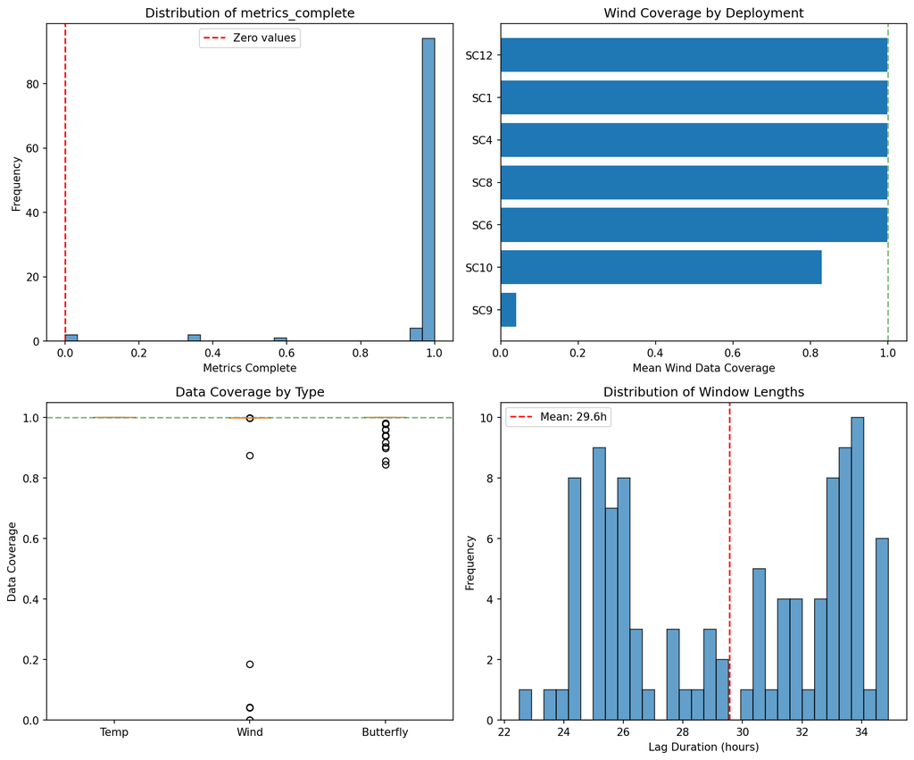

```r
# Display the diagnostic plot created earlier
knitr::include_graphics(here("analysis", "dynamic_window_analysis", "data_quality_diagnostics.png"))
```

### 5.1 Filtering Low Quality Observations

```r
# Filter observations with metrics_complete < 0.95
low_quality <- daily_data %>%
    filter(metrics_complete < 0.95)

cat("Observations to exclude (metrics_complete < 0.95):", nrow(low_quality), "\n")
```

```
Observations to exclude (metrics_complete < 0.95): 7
```

```r
cat("Percentage of dataset:", round(nrow(low_quality) / nrow(daily_data) * 100, 1), "%\n\n")
```

```
Percentage of dataset: 6.8 %
```

```r
if (nrow(low_quality) > 0) {
    cat("Excluded observations have:\n")
    cat("- Mean butterflies_95th_t_1:", round(mean(low_quality$butterflies_95th_percentile_t_1), 1), "\n")
    cat("- Mean butterflies_95th_t:", round(mean(low_quality$butterflies_95th_percentile_t), 1), "\n")
    cat("- Mean |butterfly_diff_95th|:", round(mean(abs(low_quality$butterfly_diff_95th)), 1), "\n")
    cat("- Mean metrics_complete:", round(mean(low_quality$metrics_complete), 3), "\n\n")
}
```

```
Excluded observations have:
- Mean butterflies_95th_t_1: 22.9
- Mean butterflies_95th_t: 19.2
- Mean |butterfly_diff_95th|: 7.9
- Mean metrics_complete: 0.45
```

```r
# Apply filter
daily_data <- daily_data %>%
    filter(metrics_complete >= 0.95)

cat("After filtering:\n")
```

```
After filtering:
```

```r
cat("- Observations retained:", nrow(daily_data), "\n")
```

```
- Observations retained: 96
```

```r
cat("- Mean butterflies_95th_t_1:", round(mean(daily_data$butterflies_95th_percentile_t_1), 1), "\n")
```

```
- Mean butterflies_95th_t_1: 123.1
```

```r
cat("- Mean butterflies_95th_t:", round(mean(daily_data$butterflies_95th_percentile_t), 1), "\n")
```

```
- Mean butterflies_95th_t: 113.8
```

```r
cat("- Mean |butterfly_diff_95th|:", round(mean(abs(daily_data$butterfly_diff_95th)), 1), "\n")
```

```
- Mean |butterfly_diff_95th|: 58
```

```r
cat("- Mean metrics_complete:", round(mean(daily_data$metrics_complete), 3), "\n")
```

```
- Mean metrics_complete: 0.996
```

**Rationale for exclusion**: The 7 excluded observations (6.8% of dataset) have relatively small butterfly counts (mean 95th percentile: 22.9 vs 123.1 for kept data) and incomplete weather data that could bias model estimates.

## 6 Correlation Matrix: All Candidate Predictors

This correlation matrix shows all potential fixed effects to help identify multicollinearity and guide variable selection.

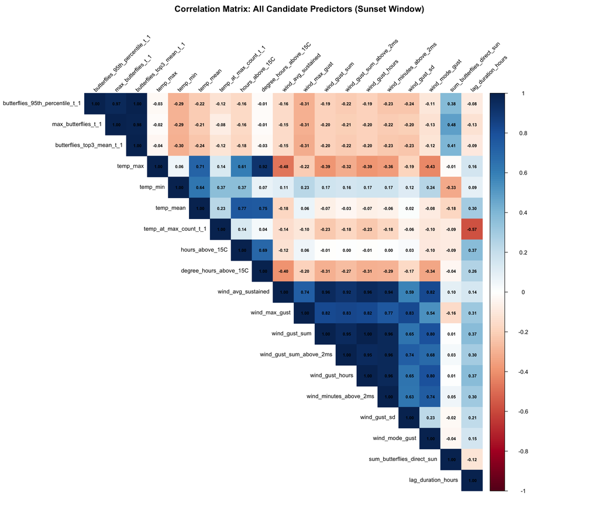

```r
# Select all candidate predictors that exist in the dataset
available_predictors <- all_predictors[all_predictors %in% names(daily_data)]

# Create correlation matrix
predictor_data <- daily_data %>%
    select(all_of(available_predictors)) %>%
    na.omit()

cor_matrix <- cor(predictor_data)

# Create correlation plot
corrplot(cor_matrix,
    method = "color",
    type = "upper",
    order = "original",
    tl.cex = 0.8,
    tl.col = "black",
    tl.srt = 45,
    addCoef.col = "black",
    number.cex = 0.6,
    title = "Correlation Matrix: All Candidate Predictors (Sunset Window)",
    mar = c(0, 0, 2, 0)
)
```

```r
# Print correlation matrix as table
kable(round(cor_matrix, 3),
      caption = "Correlation coefficients for all candidate predictors")
```

Correlation coefficients for all candidate predictors

|  | butterflies_95th_percentile_t_1 | max_butterflies_t_1 | butterflies_top3_mean_t_1 | temp_max | temp_min | temp_mean | temp_at_max_count_t_1 | hours_above_15C | degree_hours_above_15C | wind_avg_sustained | wind_max_gust | wind_gust_sum | wind_gust_sum_above_2ms | wind_gust_hours | wind_minutes_above_2ms | wind_gust_sd | wind_mode_gust | sum_butterflies_direct_sun | lag_duration_hours |
| --- | --- | --- | --- | --- | --- | --- | --- | --- | --- | --- | --- | --- | --- | --- | --- | --- | --- | --- | --- |
| butterflies_95th_percentile_t_1 | 1.000 | 0.968 | 0.995 | -0.027 | -0.294 | -0.219 | -0.124 | -0.163 | -0.014 | -0.155 | -0.306 | -0.194 | -0.220 | -0.194 | -0.233 | -0.240 | -0.110 | 0.381 | -0.082 |
| max_butterflies_t_1 | 0.968 | 1.000 | 0.982 | -0.016 | -0.293 | -0.215 | -0.076 | -0.160 | -0.014 | -0.151 | -0.307 | -0.198 | -0.207 | -0.198 | -0.216 | -0.204 | -0.129 | 0.480 | -0.126 |
| butterflies_top3_mean_t_1 | 0.995 | 0.982 | 1.000 | -0.038 | -0.302 | -0.237 | -0.118 | -0.177 | -0.028 | -0.154 | -0.310 | -0.196 | -0.219 | -0.196 | -0.226 | -0.233 | -0.117 | 0.406 | -0.093 |
| temp_max | -0.027 | -0.016 | -0.038 | 1.000 | 0.056 | 0.711 | 0.139 | 0.606 | 0.919 | -0.476 | -0.218 | -0.388 | -0.317 | -0.388 | -0.364 | -0.186 | -0.427 | -0.012 | 0.157 |
| temp_min | -0.294 | -0.293 | -0.302 | 0.056 | 1.000 | 0.639 | 0.366 | 0.365 | 0.070 | 0.107 | 0.232 | 0.168 | 0.156 | 0.168 | 0.167 | 0.118 | 0.240 | -0.330 | 0.086 |
| temp_mean | -0.219 | -0.215 | -0.237 | 0.711 | 0.639 | 1.000 | 0.230 | 0.767 | 0.754 | -0.178 | 0.064 | -0.067 | -0.030 | -0.067 | -0.059 | 0.016 | -0.084 | -0.177 | 0.297 |
| temp_at_max_count_t_1 | -0.124 | -0.076 | -0.118 | 0.139 | 0.366 | 0.230 | 1.000 | 0.138 | 0.039 | -0.140 | -0.105 | -0.229 | -0.177 | -0.229 | -0.177 | -0.058 | -0.101 | -0.085 | -0.574 |
| hours_above_15C | -0.163 | -0.160 | -0.177 | 0.606 | 0.365 | 0.767 | 0.138 | 1.000 | 0.694 | -0.121 | 0.058 | -0.006 | 0.003 | -0.006 | 0.002 | 0.029 | -0.096 | -0.087 | 0.374 |
| degree_hours_above_15C | -0.014 | -0.014 | -0.028 | 0.919 | 0.070 | 0.754 | 0.039 | 0.694 | 1.000 | -0.396 | -0.196 | -0.309 | -0.269 | -0.309 | -0.294 | -0.169 | -0.340 | -0.037 | 0.258 |
| wind_avg_sustained | -0.155 | -0.151 | -0.154 | -0.476 | 0.107 | -0.178 | -0.140 | -0.121 | -0.396 | 1.000 | 0.740 | 0.956 | 0.917 | 0.956 | 0.938 | 0.586 | 0.824 | 0.096 | 0.142 |
| wind_max_gust | -0.306 | -0.307 | -0.310 | -0.218 | 0.232 | 0.064 | -0.105 | 0.058 | -0.196 | 0.740 | 1.000 | 0.824 | 0.830 | 0.824 | 0.767 | 0.830 | 0.539 | -0.159 | 0.314 |
| wind_gust_sum | -0.194 | -0.198 | -0.196 | -0.388 | 0.168 | -0.067 | -0.229 | -0.006 | -0.309 | 0.956 | 0.824 | 1.000 | 0.953 | 1.000 | 0.963 | 0.648 | 0.800 | 0.006 | 0.372 |
| wind_gust_sum_above_2ms | -0.220 | -0.207 | -0.219 | -0.317 | 0.156 | -0.030 | -0.177 | 0.003 | -0.269 | 0.917 | 0.830 | 0.953 | 1.000 | 0.953 | 0.962 | 0.738 | 0.683 | 0.033 | 0.299 |
| wind_gust_hours | -0.194 | -0.198 | -0.196 | -0.388 | 0.168 | -0.067 | -0.229 | -0.006 | -0.309 | 0.956 | 0.824 | 1.000 | 0.953 | 1.000 | 0.963 | 0.648 | 0.800 | 0.006 | 0.372 |
| wind_minutes_above_2ms | -0.233 | -0.216 | -0.226 | -0.364 | 0.167 | -0.059 | -0.177 | 0.002 | -0.294 | 0.938 | 0.767 | 0.963 | 0.962 | 0.963 | 1.000 | 0.630 | 0.743 | 0.053 | 0.300 |
| wind_gust_sd | -0.240 | -0.204 | -0.233 | -0.186 | 0.118 | 0.016 | -0.058 | 0.029 | -0.169 | 0.586 | 0.830 | 0.648 | 0.738 | 0.648 | 0.630 | 1.000 | 0.226 | -0.022 | 0.211 |
| wind_mode_gust | -0.110 | -0.129 | -0.117 | -0.427 | 0.240 | -0.084 | -0.101 | -0.096 | -0.340 | 0.824 | 0.539 | 0.800 | 0.683 | 0.800 | 0.743 | 0.226 | 1.000 | -0.039 | 0.153 |
| sum_butterflies_direct_sun | 0.381 | 0.480 | 0.406 | -0.012 | -0.330 | -0.177 | -0.085 | -0.087 | -0.037 | 0.096 | -0.159 | 0.006 | 0.033 | 0.006 | 0.053 | -0.022 | -0.039 | 1.000 | -0.116 |
| lag_duration_hours | -0.082 | -0.126 | -0.093 | 0.157 | 0.086 | 0.297 | -0.574 | 0.374 | 0.258 | 0.142 | 0.314 | 0.372 | 0.299 | 0.372 | 0.300 | 0.211 | 0.153 | -0.116 | 1.000 |

### 6.1 Highly Correlated Pairs (|r| > 0.7)

```r
# Find pairs with high correlation
high_cor_pairs <- data.frame()

for (i in 1:(nrow(cor_matrix)-1)) {
    for (j in (i+1):ncol(cor_matrix)) {
        cor_val <- cor_matrix[i, j]
        if (abs(cor_val) > 0.7) {
            high_cor_pairs <- rbind(
                high_cor_pairs,
                data.frame(
                    Var1 = rownames(cor_matrix)[i],
                    Var2 = colnames(cor_matrix)[j],
                    Correlation = round(cor_val, 3)
                )
            )
        }
    }
}

if (nrow(high_cor_pairs) > 0) {
    high_cor_pairs <- high_cor_pairs %>%
        arrange(desc(abs(Correlation)))

    kable(high_cor_pairs,
          caption = "Predictor pairs with |r| > 0.7 (potential multicollinearity issues)")
} else {
    cat("No predictor pairs with |r| > 0.7\n")
}
```

Predictor pairs with |r| > 0.7 (potential multicollinearity issues)

| Var1 | Var2 | Correlation |
| --- | --- | --- |
| wind_gust_sum | wind_gust_hours | 1.000 |
| butterflies_95th_percentile_t_1 | butterflies_top3_mean_t_1 | 0.995 |
| max_butterflies_t_1 | butterflies_top3_mean_t_1 | 0.982 |
| butterflies_95th_percentile_t_1 | max_butterflies_t_1 | 0.968 |
| wind_gust_sum | wind_minutes_above_2ms | 0.963 |
| wind_gust_hours | wind_minutes_above_2ms | 0.963 |
| wind_gust_sum_above_2ms | wind_minutes_above_2ms | 0.962 |
| wind_avg_sustained | wind_gust_sum | 0.956 |
| wind_avg_sustained | wind_gust_hours | 0.956 |
| wind_gust_sum | wind_gust_sum_above_2ms | 0.953 |
| wind_gust_sum_above_2ms | wind_gust_hours | 0.953 |
| wind_avg_sustained | wind_minutes_above_2ms | 0.938 |
| temp_max | degree_hours_above_15C | 0.919 |
| wind_avg_sustained | wind_gust_sum_above_2ms | 0.917 |
| wind_max_gust | wind_gust_sum_above_2ms | 0.830 |
| wind_max_gust | wind_gust_sd | 0.830 |
| wind_avg_sustained | wind_mode_gust | 0.824 |
| wind_max_gust | wind_gust_sum | 0.824 |
| wind_max_gust | wind_gust_hours | 0.824 |
| wind_gust_sum | wind_mode_gust | 0.800 |
| wind_gust_hours | wind_mode_gust | 0.800 |
| temp_mean | hours_above_15C | 0.767 |
| wind_max_gust | wind_minutes_above_2ms | 0.767 |
| temp_mean | degree_hours_above_15C | 0.754 |
| wind_minutes_above_2ms | wind_mode_gust | 0.743 |
| wind_avg_sustained | wind_max_gust | 0.740 |
| wind_gust_sum_above_2ms | wind_gust_sd | 0.738 |
| temp_max | temp_mean | 0.711 |

## 7 Next Steps

**Review the correlation matrix** to make decisions about:

1. Which butterfly baseline metric to use (95th percentile, max, or top3 mean)
2. Which temperature metrics to include (avoid highly correlated pairs)
3. Which wind metrics to include (many are highly correlated)
4. Whether to include `lag_duration_hours` as a random effect or fixed effect

Once predictor selection is finalized, we’ll proceed to: - Model fitting (M and B models as in original analysis) - Model selection via AIC - Detailed analysis of top models - Comparison with original fixed-window results

**Analysis paused here for predictor review and selection.**